# Determining the quality of weight lifting

Gianluca Micchi

October 18, 2016

A teacher is considered fundamental in most human activities. One important task for teachers is to control the correct realization of an exercise. A wrong exercise can have a negative and lasting effect, for example, on health (imagine weight lifting), learning (imagine playing an instrument), etc. It is thus interesting to create new methods to identify wrong exercises.

In this project, we study how to recognize the correct realization of a weight lifting exercise out of 5 possible ones. One element of the data set is made of data identifying the performer of the exercise, the time of the experiment, and by measures of acceleration and other quantities as obtained from sensors placed on the body of the performer as well as on the weight to lift. It is a problem of supervised learning, since an expert has classified each element in the data set. The experiment is performed on 6 different untrained men under the supervision of the aforementioned expert.

We can obtain a good predicting ability if we train 5 logistic regression classifiers, one for each possible outcome, and then mix their results. The accuracy we obtain is close to 75 % and is almost constant on the training and the cross validation test, which means that we do not overfit the data.

Random forest given a much better result, around 98%, at the price of a longer training time.

## Pre-processing the data

Let’s take a look at the data we have:

```r
training <- read.csv("training.csv")
testing <- read.csv("testing.csv")
str(training)
```

```
## 'data.frame':    19622 obs. of  160 variables:
##  $ X                       : int  1 2 3 4 5 6 7 8 9 10 ...
##  $ user_name               : Factor w/ 6 levels "adelmo","carlitos",..: 2 2 2 2 2 2 2 2 2 2 ...
##  $ raw_timestamp_part_1    : int  1323084231 1323084231 1323084231 1323084232 1323084232 1323084232 1323084232 1323084232 1323084232 1323084232 ...
##  $ raw_timestamp_part_2    : int  788290 808298 820366 120339 196328 304277 368296 440390 484323 484434 ...
##  $ cvtd_timestamp          : Factor w/ 20 levels "02/12/2011 13:32",..: 9 9 9 9 9 9 9 9 9 9 ...
##  $ new_window              : Factor w/ 2 levels "no","yes": 1 1 1 1 1 1 1 1 1 1 ...
##  $ num_window              : int  11 11 11 12 12 12 12 12 12 12 ...
##  $ roll_belt               : num  1.41 1.41 1.42 1.48 1.48 1.45 1.42 1.42 1.43 1.45 ...
##  $ pitch_belt              : num  8.07 8.07 8.07 8.05 8.07 8.06 8.09 8.13 8.16 8.17 ...
##  $ yaw_belt                : num  -94.4 -94.4 -94.4 -94.4 -94.4 -94.4 -94.4 -94.4 -94.4 -94.4 ...
##  $ total_accel_belt        : int  3 3 3 3 3 3 3 3 3 3 ...
##  $ kurtosis_roll_belt      : Factor w/ 397 levels "","-0.016850",..: 1 1 1 1 1 1 1 1 1 1 ...
##  $ kurtosis_picth_belt     : Factor w/ 317 levels "","-0.021887",..: 1 1 1 1 1 1 1 1 1 1 ...
##  $ kurtosis_yaw_belt       : Factor w/ 2 levels "","#DIV/0!": 1 1 1 1 1 1 1 1 1 1 ...
```

[output cut: 86 more lines]

It is quite a large amount of columns that we have there! We can divide them in three types:

- identifiers, such as the user_name, the timestamp, and the classe, that tells which variation of the exercise was performed
- raw data from the sensors, that start with “roll”, “pitch”, “yaw”, gyros“,”accel“,”magnet"
- derived data, such as average, standard deviation, variance etc.

There seems to be a problem with the derived data: they are mostly empty or NAs, leaving just a handful of information.

For our linear model, we decide to work only with the columns that are controlled.

```r
toKeep <- grepl("user_name|^accel_|^magnet|^gyros|^roll|^pitch|^yaw|classe", names(training))
trainingTK <- training[,toKeep] # TK stands for To Keep
testingTK <- testing[,toKeep]
```

We then split the trainingTK set to have a cross-validation set at our disposal

```r
set.seed(18)
library(caret)
inTrain <- createDataPartition(y=trainingTK$classe, p=0.75, list=FALSE)
trainTK <- trainingTK[inTrain,]
crossTK <- trainingTK[-inTrain,]
```

We are left with a categorical variable (user_name), the outcome (classe), and 48 numerical (or integer) predictors in between.

## Exploratory analysis of the data

Let’s now make some plots to realize what the data looks like.

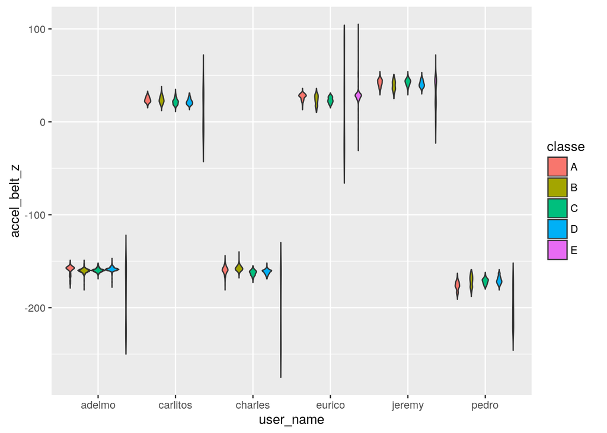

```r
library(ggplot2)
ggplot(trainingTK, aes(x = user_name, y=accel_belt_z, fill=classe)) +
        geom_violin()
```

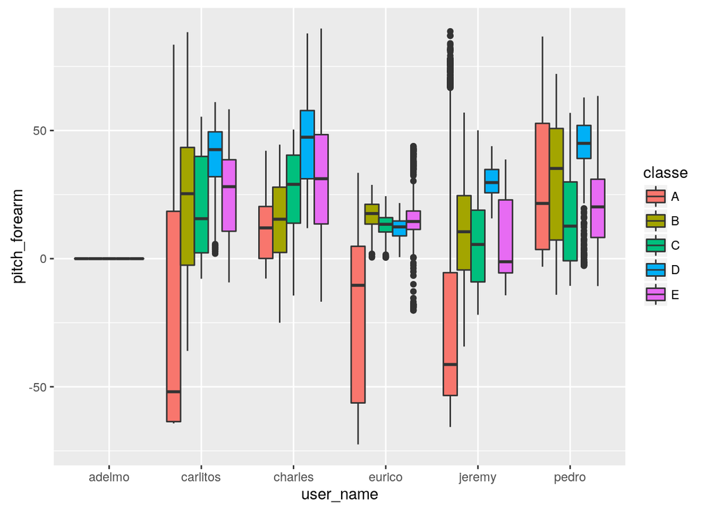

```r
ggplot(trainingTK, aes(x = user_name, y=pitch_forearm, fill=classe)) +
        geom_boxplot()
```

We see that the user is a determinant variable in the range of values that a parameter can have. To take this into account it is not sufficient to insert user_name as a variable inside the model we will fit. At first, we will first ignore this problem. We will then improve by normalizing all the variables on a per-user basis and retrain our classifiers.

## Choice of the model

We have a classification problem with lots of numerical variables.

### Logistic classifiers

The first thing I try is to train 5 logistic regression classifiers, one per each *classe* we have, and then combine their results. To combine, we predict using all 5 classifiers and take the result associated to the highest probability.

Here are the results we obtain on the training set and on the cross validation set.

```
## Confusion Matrix and Statistics
##
##           Reference
## Prediction    A    B    C    D    E
##          A 3749  401  262  194  115
##          B   79 1918  209   86  298
##          C  154  290 1793  255   95
##          D  189   51  190 1782  182
##          E   14  188  113   95 2016
##
## Overall Statistics
##
##                Accuracy : 0.7649
##                  95% CI : (0.758, 0.7717)
##     No Information Rate : 0.2843
##     P-Value [Acc > NIR] : < 2.2e-16
##
##                   Kappa : 0.7013
##  Mcnemar's Test P-Value : < 2.2e-16
##
## Statistics by Class:
##
##                      Class: A Class: B Class: C Class: D Class: E
## Sensitivity            0.8958   0.6735   0.6985   0.7388   0.7450
## Specificity            0.9077   0.9434   0.9347   0.9503   0.9659
## Pos Pred Value         0.7941   0.7405   0.6931   0.7444   0.8310
## Neg Pred Value         0.9564   0.9233   0.9362   0.9489   0.9439
## Prevalence             0.2843   0.1935   0.1744   0.1639   0.1839
## Detection Rate         0.2547   0.1303   0.1218   0.1211   0.1370
## Detection Prevalence   0.3208   0.1760   0.1758   0.1627   0.1648
## Balanced Accuracy      0.9018   0.8084   0.8166   0.8445   0.8554
```

```r
confusionMatrix(resCross, crossTK$classe)
```

```
## Confusion Matrix and Statistics
##
##           Reference
## Prediction    A    B    C    D    E
##          A 1244  156   95   50   30
##          B   34  606   73   34  100
##          C   53   91  590   92   33
##          D   60   21   61  600   62
##          E    4   75   36   28  676
##
## Overall Statistics
##
##                Accuracy : 0.7577
##                  95% CI : (0.7455, 0.7697)
##     No Information Rate : 0.2845
##     P-Value [Acc > NIR] : < 2.2e-16
##
##                   Kappa : 0.6922
##  Mcnemar's Test P-Value : < 2.2e-16
##
## Statistics by Class:
##
##                      Class: A Class: B Class: C Class: D Class: E
## Sensitivity            0.8918   0.6386   0.6901   0.7463   0.7503
## Specificity            0.9057   0.9391   0.9336   0.9502   0.9643
## Pos Pred Value         0.7898   0.7155   0.6868   0.7463   0.8254
## Neg Pred Value         0.9546   0.9155   0.9345   0.9502   0.9449
## Prevalence             0.2845   0.1935   0.1743   0.1639   0.1837
## Detection Rate         0.2537   0.1236   0.1203   0.1223   0.1378
## Detection Prevalence   0.3212   0.1727   0.1752   0.1639   0.1670
## Balanced Accuracy      0.8987   0.7888   0.8118   0.8483   0.8573
```

The accuracy is around 75% and is basically the same for the training set and the cross validation set, a hint that there is no overfitting and that a regularization method is not needed.

### Logistic regression with pre-processing the data

Let’s see what happens when scaling the data with respect to the user. We do it with the following function

```r
scaleUser <- function(df, means, sdevs, name) {
        if(dim(means)[2] != dim(sdevs)[2] | dim(means)[2] != dim(df)[2])
                stop("means and/or standard deviations are not compatible with the data frame you chose")
        if(sum(names(df) %in% c("user_name", "classe")) != 2)
                stop("user_name and classe not defined. Are you sure you submitted the correct data frame?")

        user <- which(df$user_name==name)
        cols <- !names(df) %in% c("user_name", "classe")
        m <- filter(means, user_name==name)
        s <- filter(sdevs, user_name==name)
        s[1, which(s[1, cols]==0)+1] <- 1
        df[user, cols] <- (df[user, cols]-m[rep(1, length(user)), cols])/s[rep(1, length(user)), cols]
        df
}
```

```r
library(dplyr)
means <- aggregate(trainTK, list(trainTK$user_name), function (x) if(!is.factor(x)) mean(x))
means[, "user_name"] <- means[, "Group.1"]
means <- means[, -1]
sdevs <- aggregate(trainTK, list(trainTK$user_name), function (x) if(!is.factor(x)) sd(x))
sdevs[, "user_name"] <- sdevs[, "Group.1"]
sdevs <- sdevs[, -1]
trainPP <- trainTK
for (name in unique(trainTK$user_name)) {
        trainPP <- scaleUser(trainPP, means, sdevs, name)
}
crossPP <- crossTK
for (name in unique(crossTK$user_name)) {
        crossPP <- scaleUser(crossPP, means, sdevs, name)
}
```

```
## Confusion Matrix and Statistics
##
##           Reference
## Prediction    A    B    C    D    E
##          A 3711  409  323  230  129
##          B   84 1901  241   70  287
##          C  118  290 1768  280  148
##          D  252   74  159 1636  257
##          E   20  174   76  196 1885
##
## Overall Statistics
##
##                Accuracy : 0.7407
##                  95% CI : (0.7335, 0.7477)
##     No Information Rate : 0.2843
##     P-Value [Acc > NIR] : < 2.2e-16
##
##                   Kappa : 0.6703
##  Mcnemar's Test P-Value : < 2.2e-16
##
## Statistics by Class:
##
##                      Class: A Class: B Class: C Class: D Class: E
## Sensitivity            0.8867   0.6675   0.6887   0.6783   0.6966
## Specificity            0.8964   0.9425   0.9312   0.9397   0.9612
## Pos Pred Value         0.7728   0.7360   0.6790   0.6880   0.8018
## Neg Pred Value         0.9522   0.9220   0.9340   0.9371   0.9336
## Prevalence             0.2843   0.1935   0.1744   0.1639   0.1839
## Detection Rate         0.2521   0.1292   0.1201   0.1112   0.1281
## Detection Prevalence   0.3263   0.1755   0.1769   0.1616   0.1597
## Balanced Accuracy      0.8916   0.8050   0.8100   0.8090   0.8289
```

```r
confusionMatrix(resCrossPP, crossPP$classe)
```

```
## Confusion Matrix and Statistics
##
##           Reference
## Prediction    A    B    C    D    E
##          A 1222  155  117   64   38
##          B   42  627   86   18   97
##          C   38   82  583  108   60
##          D   84   23   47  553   91
##          E    9   62   22   61  615
##
## Overall Statistics
##
##                Accuracy : 0.7341
##                  95% CI : (0.7215, 0.7464)
##     No Information Rate : 0.2845
##     P-Value [Acc > NIR] : < 2.2e-16
##
##                   Kappa : 0.662
##  Mcnemar's Test P-Value : < 2.2e-16
##
## Statistics by Class:
##
##                      Class: A Class: B Class: C Class: D Class: E
## Sensitivity            0.8760   0.6607   0.6819   0.6878   0.6826
## Specificity            0.8934   0.9386   0.9289   0.9402   0.9615
## Pos Pred Value         0.7657   0.7207   0.6693   0.6930   0.7997
## Neg Pred Value         0.9477   0.9202   0.9326   0.9389   0.9308
## Prevalence             0.2845   0.1935   0.1743   0.1639   0.1837
## Detection Rate         0.2492   0.1279   0.1189   0.1128   0.1254
## Detection Prevalence   0.3254   0.1774   0.1776   0.1627   0.1568
## Balanced Accuracy      0.8847   0.7996   0.8054   0.8140   0.8221
```

As we can see, the accuracy hasn’t changed much. If any, it has decreased!

We will ignore this model and stick with our original 5 linear regressions.

### Decision trees

We train a second model based on decision trees with the package rpart. However, we expect this to be less effective because there are many features and most of the numeric.

```r
confusionMatrix(predict(fitT), trainTK$classe)
```

```
## Confusion Matrix and Statistics
##
##           Reference
## Prediction    A    B    C    D    E
##          A 3792 1161 1192 1074  393
##          B   55  970   77  418  360
##          C  328  717 1298  920  730
##          D    0    0    0    0    0
##          E   10    0    0    0 1223
##
## Overall Statistics
##
##                Accuracy : 0.4948
##                  95% CI : (0.4867, 0.5029)
##     No Information Rate : 0.2843
##     P-Value [Acc > NIR] : < 2.2e-16
##
##                   Kappa : 0.3401
##  Mcnemar's Test P-Value : NA
##
## Statistics by Class:
##
##                      Class: A Class: B Class: C Class: D Class: E
## Sensitivity            0.9061  0.34059  0.50565   0.0000  0.45196
## Specificity            0.6373  0.92334  0.77821   1.0000  0.99917
## Pos Pred Value         0.4982  0.51596  0.32507      NaN  0.99189
## Neg Pred Value         0.9447  0.85372  0.88168   0.8361  0.89003
## Prevalence             0.2843  0.19350  0.17441   0.1639  0.18386
## Detection Rate         0.2576  0.06591  0.08819   0.0000  0.08310
## Detection Prevalence   0.5172  0.12773  0.27130   0.0000  0.08377
## Balanced Accuracy      0.7717  0.63196  0.64193   0.5000  0.72556
```

```r
confusionMatrix(predict(fitT, newdata=crossTK), crossTK$classe)
```

```
## Confusion Matrix and Statistics
##
##           Reference
## Prediction    A    B    C    D    E
##          A 1276  394  392  351  129
##          B   26  316   31  150  126
##          C   89  239  432  303  238
##          D    0    0    0    0    0
##          E    4    0    0    0  408
##
## Overall Statistics
##
##                Accuracy : 0.4959
##                  95% CI : (0.4818, 0.51)
##     No Information Rate : 0.2845
##     P-Value [Acc > NIR] : < 2.2e-16
##
##                   Kappa : 0.3413
##  Mcnemar's Test P-Value : NA
##
## Statistics by Class:
##
##                      Class: A Class: B Class: C Class: D Class: E
## Sensitivity            0.9147  0.33298  0.50526   0.0000  0.45283
## Specificity            0.6392  0.91580  0.78538   1.0000  0.99900
## Pos Pred Value         0.5020  0.48690  0.33205      NaN  0.99029
## Neg Pred Value         0.9496  0.85123  0.88260   0.8361  0.89025
## Prevalence             0.2845  0.19352  0.17435   0.1639  0.18373
## Detection Rate         0.2602  0.06444  0.08809   0.0000  0.08320
## Detection Prevalence   0.5184  0.13234  0.26529   0.0000  0.08401
## Balanced Accuracy      0.7770  0.62439  0.64532   0.5000  0.72592
```

The accuracy is less than 50% and the D outcome is never predicted. We won’t use this method.

### Random forest

Let’s try with random forests. First of all, we reduce the dimensionality, because random forest take a very long time. We do so through principal component analysis

```r
PC <- preProcess(trainTK[, 2:49], method=c("center", "scale", "pca"))
trainPC <- predict(PC, trainTK)
crossPC <- predict(PC, crossTK)
```

Then we train the forest:

```r
confusionMatrix(predict(fitRF), trainPC$classe)
```

```
## Confusion Matrix and Statistics
##
##           Reference
## Prediction    A    B    C    D    E
##          A 4185    0    0    0    0
##          B    0 2848    0    0    0
##          C    0    0 2567    0    0
##          D    0    0    0 2412    0
##          E    0    0    0    0 2706
##
## Overall Statistics
##
##                Accuracy : 1
##                  95% CI : (0.9997, 1)
##     No Information Rate : 0.2843
##     P-Value [Acc > NIR] : < 2.2e-16
##
##                   Kappa : 1
##  Mcnemar's Test P-Value : NA
##
## Statistics by Class:
##
##                      Class: A Class: B Class: C Class: D Class: E
## Sensitivity            1.0000   1.0000   1.0000   1.0000   1.0000
## Specificity            1.0000   1.0000   1.0000   1.0000   1.0000
## Pos Pred Value         1.0000   1.0000   1.0000   1.0000   1.0000
## Neg Pred Value         1.0000   1.0000   1.0000   1.0000   1.0000
## Prevalence             0.2843   0.1935   0.1744   0.1639   0.1839
## Detection Rate         0.2843   0.1935   0.1744   0.1639   0.1839
## Detection Prevalence   0.2843   0.1935   0.1744   0.1639   0.1839
## Balanced Accuracy      1.0000   1.0000   1.0000   1.0000   1.0000
```

```r
confusionMatrix(predict(fitRF, newdata=crossPC), crossPC$classe)
```

```
## Confusion Matrix and Statistics
##
##           Reference
## Prediction    A    B    C    D    E
##          A 1388   21    0    0    0
##          B    1  917   15    3    1
##          C    2   11  836   37   10
##          D    2    0    4  763    5
##          E    2    0    0    1  885
##
## Overall Statistics
##
##                Accuracy : 0.9765
##                  95% CI : (0.9719, 0.9806)
##     No Information Rate : 0.2845
##     P-Value [Acc > NIR] : < 2.2e-16
##
##                   Kappa : 0.9703
##  Mcnemar's Test P-Value : 1.065e-10
##
## Statistics by Class:
##
##                      Class: A Class: B Class: C Class: D Class: E
## Sensitivity            0.9950   0.9663   0.9778   0.9490   0.9822
## Specificity            0.9940   0.9949   0.9852   0.9973   0.9993
## Pos Pred Value         0.9851   0.9787   0.9330   0.9858   0.9966
## Neg Pred Value         0.9980   0.9919   0.9953   0.9901   0.9960
## Prevalence             0.2845   0.1935   0.1743   0.1639   0.1837
## Detection Rate         0.2830   0.1870   0.1705   0.1556   0.1805
## Detection Prevalence   0.2873   0.1911   0.1827   0.1578   0.1811
## Balanced Accuracy      0.9945   0.9806   0.9815   0.9732   0.9907
```

Finally, we get to the result that random forest are the best algorithm to find the result, with an accuracy of 98%. However, the time needed to train this system is very large compared to the time needed to train the logistic regressors (more than ten times larger?).